# La curva de Phillips en España

## 1. Introducción

En la ciencia de la economía, existe un modelo que relaciona la inflación y el paro negativamente, es decir, con una correlación negativa. Más en concreto, cuando los precios suben, el nivel de paro baja, y al contrario.

El primer economista que tuvo esta idea fue **William Phillips**, aunque él no relacionó el paro con la inflación, sino con los salarios. Sin embargo, **Paul Samuelson** y **Robert Solow**, economistas muy prestigiosos del siglo XIX, fueron los que evoluvcionaron el modelo, incluyendo la inflación.

Este modelo, denominado como [*Curva de Phillips*](https://es.wikipedia.org/wiki/Curva_de_Phillips) por la relación negativa que tienen los gráficos de la inflación y del paro, sigue hasta hoy en día teniendo importancia para los desarrolladores de las políticas económicas.

En este ejercicio, quiero examinar si el modélo se aplica en España durante los últimos años.

## 2. Sobre los datos

La entidad responsable de las estadísticas del Paro y de la Inflación es el **Instituto Nacional de Estadística (INE)**.

Los datos están disponibles para descargar, tanto los del [Paro](https://ine.es/jaxiT3/Tabla.htm?t=4086&L=0) como los de la [Inflación](https://ine.es/jaxiT3/Tabla.htm?t=50903&L=0).

Sobre los datos del **Paro**:

- Descargo las tasas generales del paro que incluyen toda la población activa en España, es decir, todos los generos, todas las edades y en todos los sectores
- Los datos son trimestrales
- Incluyen desde el primer trimestre del 2002 hasta el último trimestre del 2022
- El formato del archivo que descargo es de *csv*

Sobre los datos de la **Inflación**:

- Descargo la variación anual del Indice de Precios de Consumo (IPC), es decir, la inflación general. Incluye todas la categorías de productos
- Los datos son mensuales
- Incluyen entre el enero de 2002 y el enero de 2023
- El formato del archivo que descargo es de *csv*

## 3. Carga, manipulación y limpieza de datos

Hago uso de la libreria `tidyverse`

##### 3.1 Los datos del **Paro**:

```r
paro <- read.csv(file = "./Paro.csv",
                 dec = ",",
                 sep = ";")

# Solo necesito las dos últimas columnas y llamo la columna con los datos del paro como 'Paro'
paro <- paro[, 3:4]
colnames(paro)[2] <- "Paro"

glimpse(paro)
```

```
## Rows: 84
## Columns: 2
## $ Periodo <chr> "2022T4", "2022T3", "2022T2", "2022T1", "2021T4", "2021T3", "2…
## $ Paro    <dbl> 12.87, 12.67, 12.48, 13.65, 13.33, 14.57, 15.26, 15.98, 16.13,…
```

##### 3.2 Los datos de la **Inflación**:

**Nota** : Me salen errores si pongo algunas opciones como: `header = TRUE` o `skip = 1` etc. Tampoco acepta la opción `dec = ","`. Así que abro el fichero con esta manera y voy cambando mi dataframe `ipc` según mis necesidades

```r
ipc <- read.csv("./Inflacion.csv",
                sep = ";",
                header = FALSE,
                fill = TRUE)

# Solo necesito las dos últimas columnas, y les pongo los nombres 'Periodo' e 'Inflación'. También, no necesito las dos primeras filas que tienen los nombres del dataframe  y la inflación del enero de 2023
ipc <- ipc[-1:-2, 3:4]
colnames(ipc) <- c("Periodo", "Inflación")

# En España, se usa el coma (',') como delimiter. Sin embargo, R recononoce como delimiter el punto (.). Así que en la fila Inflación, cambio el ',' con el '.'
ipc$Inflación <- str_replace_all(ipc$Inflación, ",", ".")
#Luego, convierto los datos de la fila en números
ipc$Inflación <- as.numeric(ipc$Inflación)

glimpse(ipc)
```

```
## Rows: 252
## Columns: 2
## $ Periodo   <chr> "2022M12", "2022M11", "2022M10", "2022M09", "2022M08", "2022…
## $ Inflación <dbl> 5.7, 6.8, 7.3, 8.9, 10.5, 10.8, 10.2, 8.7, 8.3, 9.8, 7.6, 6.…
```

Los datos del *Paro* son **trimestrales**. Sin embargo, los datos de la *Inflación* son **mensuales**. Así que tengo que transformar los últimos en trimestrales

```r
# El periodo está escrito con la forma de: Año, seguido por la letra M y el mes que corresponde.
# Necesito crear dos nuevas filas, una para el año y otra para el mes de cada dato.
# Para hacerlo, tengo que separar el texto y asignarlo en dos nuevas columnas, cuyos nombres serán 'Año'y 'Mes'
ipc[, 3:4] <- str_split_fixed(ipc$Periodo, pattern = "M", n = 2)
colnames(ipc)[3:4] <- c("Año", "Mes")

# Cambio el típo de las columnas
ipc$Año <- as.numeric(ipc$Año)
ipc$Mes <- as.numeric(ipc$Mes)

# Creo un dataframe con los meses de cada trimestre
trimestres <- matrix(1:12, nrow = 3, ncol = 4)

# Creo una función que conventirá el mes al su trimestre (1o, 2o, 3o o 4o)
fn_trimestre <- function(mes){
  resultado <- which(trimestres == mes, arr.ind = TRUE)
  return(resultado[2])
}

# Lo aplico en una nueva columna
ipc$Trimestre <- sapply(ipc$Mes, fn_trimestre)

# La inflación de cada trimestre, es la media de los tres meses:
  ipc <- ipc %>%
  group_by(Año, Trimestre) %>%
  summarise("Inflación" = round(mean(Inflación), 2)) %>%
    arrange(desc(Año), desc(Trimestre))
```

[output not shown]

```r
# Creo una nueva columna que tiene el mismo formato que la columna 'Periodo' del dataframe paro, es decir, el año seguido por T y el trimestre.
ipc$Periodo <- paste(ipc$Año, ipc$Trimestre, sep = "T")

glimpse(ipc)
```

```
## Rows: 84
## Columns: 4
## Groups: Año [21]
## $ Año       <dbl> 2022, 2022, 2022, 2022, 2021, 2021, 2021, 2021, 2020, 2020, …
## $ Trimestre <int> 4, 3, 2, 1, 4, 3, 2, 1, 4, 3, 2, 1, 4, 3, 2, 1, 4, 3, 2, 1, …
## $ Inflación <dbl> 6.60, 10.07, 9.07, 7.83, 5.80, 3.40, 2.53, 0.60, -0.70, -0.5…
## $ Periodo   <chr> "2022T4", "2022T3", "2022T2", "2022T1", "2021T4", "2021T3", …
```

#### 3.3 Limpieza de los ‘Outliers’

Pongo los dos datos en un dataframe

**Nota**: Hago uso del `left_join` porque quiero tener las columnas `Año` y `Trimestre` para poder usar más facil el formato `Dates` que lo necesito para mi gráfico.

```r
ipc_paro <- paro %>%
  select(Periodo, Paro) %>%
  left_join(ipc, by = "Periodo")
```

Hago uso del `boxplot()` para ver si tengo outliers. Espero tener en los datos de Inflación, debido a la situación en el último año.

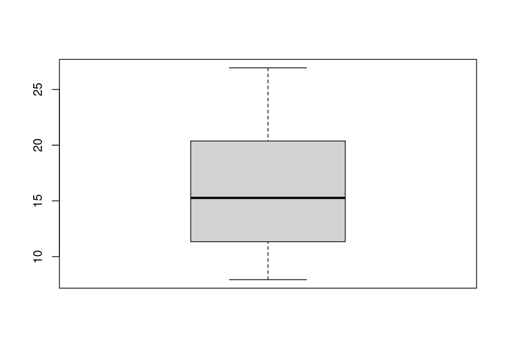

```r
#Empiezo con los datos del paro
boxplot(ipc_paro$Paro, outcol = "red")
```

Veo que los datos del paro no tienen outliers.

Sigo con los de la inflación

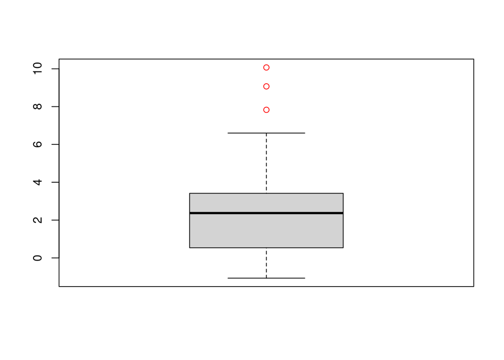

```r
# Examino también los datos de la Inflación, la cual ha subido extremadamente los últimos meses del 2022
boxplot(ipc_paro$Inflación, outcol = "red")
```

```r
mean <- mean(ipc_paro$Inflación)
std <- sd(ipc_paro$Inflación)

Tmin <- mean-(3*std)
Tmax <- mean+(3*std)

ipc_paro <- subset(ipc_paro, ipc_paro$Inflación > Tmin & ipc_paro$Inflación < Tmax)
glimpse(ipc_paro)
```

```
## Rows: 82
## Columns: 5
## $ Periodo   <chr> "2022T4", "2022T1", "2021T4", "2021T3", "2021T2", "2021T1", …
## $ Paro      <dbl> 12.87, 13.65, 13.33, 14.57, 15.26, 15.98, 16.13, 16.26, 15.3…
## $ Año       <dbl> 2022, 2022, 2021, 2021, 2021, 2021, 2020, 2020, 2020, 2020, …
## $ Trimestre <int> 4, 1, 4, 3, 2, 1, 4, 3, 2, 1, 4, 3, 2, 1, 4, 3, 2, 1, 4, 3, …
## $ Inflación <dbl> 6.60, 7.83, 5.80, 3.40, 2.53, 0.60, -0.70, -0.50, -0.63, 0.6…
```

## 4. Gráfico

Para que sea mejor mostrado el gráfico, pongo una columna de formato `Date`. Como no existe función para formato de año y trimestres (sí que existe para cuartos), pondré la fecha como año y mes. En el gráfico solo quiero mostrar el año.

```r
ipc_paro$Dates <- as.Date(paste(as.character(ipc_paro$Año),
                                as.character(ipc_paro$Trimestre), "1",
                                sep = "-"),
                          "%Y-%m-%d")

glimpse(ipc_paro)
```

```
## Rows: 82
## Columns: 6
## $ Periodo   <chr> "2022T4", "2022T1", "2021T4", "2021T3", "2021T2", "2021T1", …
## $ Paro      <dbl> 12.87, 13.65, 13.33, 14.57, 15.26, 15.98, 16.13, 16.26, 15.3…
## $ Año       <dbl> 2022, 2022, 2021, 2021, 2021, 2021, 2020, 2020, 2020, 2020, …
## $ Trimestre <int> 4, 1, 4, 3, 2, 1, 4, 3, 2, 1, 4, 3, 2, 1, 4, 3, 2, 1, 4, 3, …
## $ Inflación <dbl> 6.60, 7.83, 5.80, 3.40, 2.53, 0.60, -0.70, -0.50, -0.63, 0.6…
## $ Dates     <date> 2022-04-01, 2022-01-01, 2021-04-01, 2021-03-01, 2021-02-01,…
```

Pongo mis datos en un gráfico para examinar si la curva de la Inflación es opuesta a la curva del Paro

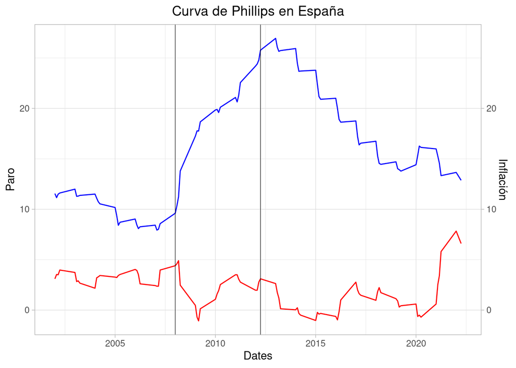

```r
ggplot(data = ipc_paro, aes(x = Dates))+
  geom_line(aes(y = Paro), colour = "blue")+
  geom_line(aes(y = Inflación), colour = "red")+
  # Marco los años 2008 y 2012 por la crisis económica
  geom_vline(xintercept = as.Date("2008-1-1", "%Y-%m-%d"), color = "black", linewidth = 0.2)+
  geom_vline(xintercept = as.Date("2012-4-1", "%Y-%m-%d"), color = "black", linewidth = 0.2)+
  scale_y_continuous(name = "Paro",
                     sec.axis = sec_axis(trans = ~., name = "Inflación"))+
  labs(title = "Curva de Phillips en España",)+
  theme_light()+
  theme(plot.title = element_text(hjust = 0.5))
```

## 5. Conclusiones

Parece que, en general, sí que hay una relación negativa entre el paro y la inflación en España. Sin embargo, la crisis económica que comenzó en 2008 y, más o menos, terminó el 2012, hizo que el paro alcanzase máximos históricos y con una gravedad más alta que la baja de la inflamación los últimos años de la crisis.